# Regression Models Course Project

# Executive summary

You work for Motor Trend, a magazine about the automobile industry. Looking at a data set of a collection of cars, they are interested in exploring the relationship between a set of variables and miles per gallon (MPG) (outcome). They are particularly interested in the following two questions:

- Is an automatic or manual transmission better for MPG
- Quantify the MPG difference between automatic and manual transmissions

# Data processing

library(datasets); data(mtcars)

# 1. Is an automatic or manual transmission better for MPG

First, an exploratory data analysis plot is performed

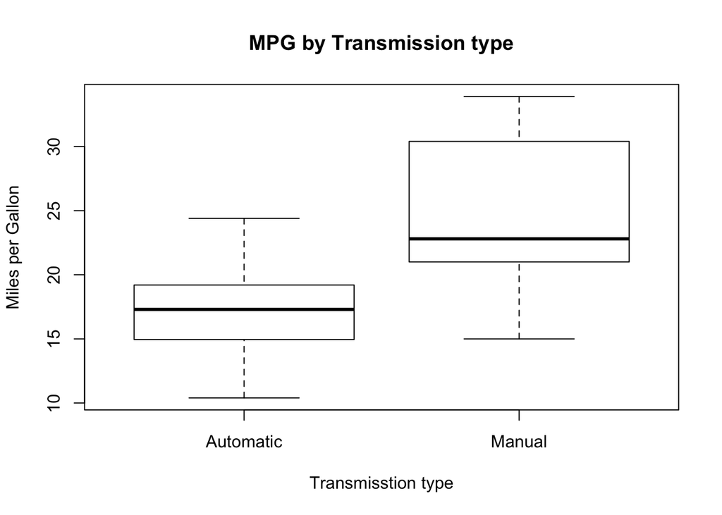

```r
mtcars$am <- factor(mtcars$am,labels=c('Automatic','Manual'))
boxplot(mpg ~ am, data=mtcars, main="MPG by Transmission type", xlab="Transmisstion type", ylab="Miles per Gallon")
```

According, to the boxplot shown above, the Manual transmission is better for MPG than the Automatic transmissiom type.

Next, a t-test is performed. The null hypothesis is that manual and automatic transmissions have the same performance.

```r
t.test(mpg~am, data=mtcars)
```

```
##
##  Welch Two Sample t-test
##
## data:  mpg by am
## t = -3.7671, df = 18.332, p-value = 0.001374
## alternative hypothesis: true difference in means is not equal to 0
## 95 percent confidence interval:
##  -11.280194  -3.209684
## sample estimates:
## mean in group Automatic    mean in group Manual
##                17.14737                24.39231
```

With a 95 percent confidence interval of [-11.280194 -3.209684] and p-value= 0.001374, we can reject the null hypothesis. The hypothesis testing indicated that a manual transmission is better than an automatic transmission for MPG.

# 2. Quantify the MPG difference between automatic and manual transmissions

First, a simple linear regression is performed

```r
fit1 <- lm(mpg~am, data = mtcars)
summary(fit1)
```

```
##
## Call:
## lm(formula = mpg ~ am, data = mtcars)
##
## Residuals:
##     Min      1Q  Median      3Q     Max
## -9.3923 -3.0923 -0.2974  3.2439  9.5077
##
## Coefficients:
##             Estimate Std. Error t value Pr(>|t|)
## (Intercept)   17.147      1.125  15.247 1.13e-15 ***
## amManual       7.245      1.764   4.106 0.000285 ***
## ---
## Signif. codes:  0 '***' 0.001 '**' 0.01 '*' 0.05 '.' 0.1 ' ' 1
##
## Residual standard error: 4.902 on 30 degrees of freedom
## Multiple R-squared:  0.3598, Adjusted R-squared:  0.3385
## F-statistic: 16.86 on 1 and 30 DF,  p-value: 0.000285
```

With R^2 = 0.3598, this model only explains approximately 36% of the variance. Therefore, more regressors need to be considered for explaining the difference between automatic and manual transmission. This, is done using the R function step(), which perform variable selection.

```r
fit2 <- step(lm(mpg ~ .,data = mtcars))
```

```r
summary(fit2)
```

```
##
## Call:
## lm(formula = mpg ~ wt + qsec + am, data = mtcars)
##
## Residuals:
##     Min      1Q  Median      3Q     Max
## -3.4811 -1.5555 -0.7257  1.4110  4.6610
##
## Coefficients:
##             Estimate Std. Error t value Pr(>|t|)
## (Intercept)   9.6178     6.9596   1.382 0.177915
## wt           -3.9165     0.7112  -5.507 6.95e-06 ***
## qsec          1.2259     0.2887   4.247 0.000216 ***
## amManual      2.9358     1.4109   2.081 0.046716 *
## ---
## Signif. codes:  0 '***' 0.001 '**' 0.01 '*' 0.05 '.' 0.1 ' ' 1
##
## Residual standard error: 2.459 on 28 degrees of freedom
## Multiple R-squared:  0.8497, Adjusted R-squared:  0.8336
## F-statistic: 52.75 on 3 and 28 DF,  p-value: 1.21e-11
```

The results show that including am, qsec and wt as regressors 85 % of the variance is explained (R^2 = 0.8497). The best linear regression fit, includes then am, qsec and wt as regressors.

```r
fit1 <- lm(mpg~am + qsec + wt, data = mtcars)
summary(fit1)
```

```
##
## Call:
## lm(formula = mpg ~ am + qsec + wt, data = mtcars)
##
## Residuals:
##     Min      1Q  Median      3Q     Max
## -3.4811 -1.5555 -0.7257  1.4110  4.6610
##
## Coefficients:
##             Estimate Std. Error t value Pr(>|t|)
## (Intercept)   9.6178     6.9596   1.382 0.177915
## amManual      2.9358     1.4109   2.081 0.046716 *
## qsec          1.2259     0.2887   4.247 0.000216 ***
## wt           -3.9165     0.7112  -5.507 6.95e-06 ***
## ---
## Signif. codes:  0 '***' 0.001 '**' 0.01 '*' 0.05 '.' 0.1 ' ' 1
##
## Residual standard error: 2.459 on 28 degrees of freedom
## Multiple R-squared:  0.8497, Adjusted R-squared:  0.8336
## F-statistic: 52.75 on 3 and 28 DF,  p-value: 1.21e-11
```